# Practical Machine Learning Final Project

## Background

Using devices such as Jawbone Up, Nike FuelBand, and Fitbit it is now possible to collect a large amount of data about personal activity relatively inexpensively. These type of devices are part of the quantified self movement - a group of enthusiasts who take measurements about themselves regularly to improve their health, to find patterns in their behavior, or because they are tech geeks. One thing that people regularly do is quantify how much of a particular activity they do, but they rarely quantify how well they do it. In this project, our goal will be to use data from accelerometers on the belt, forearm, arm, and dumbell of 6 participants to quantify how well they do it. They were asked to perform barbell lifts correctly and incorrectly in 5 different ways. More information is available from the website here: http://groupware.les.inf.puc-rio.br/har (see the section on the Weight Lifting Exercise Dataset).

The training data for this project are available here: https://d396qusza40orc.cloudfront.net/predmachlearn/pml-training.csv

The test data are available here: https://d396qusza40orc.cloudfront.net/predmachlearn/pml-testing.csv

The data for this project come from this source: http://groupware.les.inf.puc-rio.br/har If you use the document you create for this class for any purpose please cite them as they have been very generous in allowing their data to be used for this kind of assignment.

## Loading & Processing the Datasets

Load the Training & Test Dataset

```r
library(data.table, quietly=TRUE)
library(caret, quietly=TRUE)
library(randomForest, quietly=TRUE)
```

```r
library(rpart, quietly=TRUE)
library(rpart.plot, quietly=TRUE)


dfTrain <- read.csv("pml-training.csv",na.strings = c('NA','#DIV/0!',''))

dfTest <- read.csv("pml-testing.csv",na.strings = c('NA','#DIV/0!',''))
```

# Split the Training Dataset into two parts

```r
tempTrain <- createDataPartition(dfTrain$classe, p=0.6, list=FALSE)
tempTraining <- dfTrain[tempTrain, ]
tempTesting <- dfTrain[-tempTrain, ]
dim(tempTraining); dim(tempTesting)
```

```
## [1] 11776   160
```

```
## [1] 7846  160
```

# Process & clean the data

```r
nzv <- nearZeroVar(tempTraining, saveMetrics=TRUE)
tempTraining <- tempTraining[,nzv$nzv==FALSE]

nzv<- nearZeroVar(tempTesting,saveMetrics=TRUE)
tempTesting <- tempTesting[,nzv$nzv==FALSE]
tempTraining <- tempTraining[c(-1)]
trainingV3 <- tempTraining
for(i in 1:length(tempTraining)) {
    if( sum( is.na( tempTraining[, i] ) ) /nrow(tempTraining) >= .7) {
        for(j in 1:length(trainingV3)) {
            if( length( grep(names(tempTraining[i]), names(trainingV3)[j]) ) == 1)  {
                trainingV3 <- trainingV3[ , -j]
            }
        }
    }
}
tempTraining <- trainingV3
rm(trainingV3)
clean1 <- colnames(tempTraining)
clean2 <- colnames(tempTraining[, -58])
tempTesting <- tempTesting[clean1]
dfTest <- dfTest[clean2]


dim(tempTesting)
```

```
## [1] 7846   58
```

```r
dim(dfTest)
```

```
## [1] 20 57
```

## Coerce datasets into same type

```r
for (i in 1:length(dfTest) ) {
    for(j in 1:length(tempTraining)) {
        if( length( grep(names(tempTraining[i]), names(dfTest)[j]) ) == 1)  {
            class(dfTest[j]) <- class(tempTraining[i])
        }
    }
}

dfTest <- rbind(tempTraining[2, -58], dfTest)
dfTest <- dfTest[-1,]
```

# Predict using Random Forests

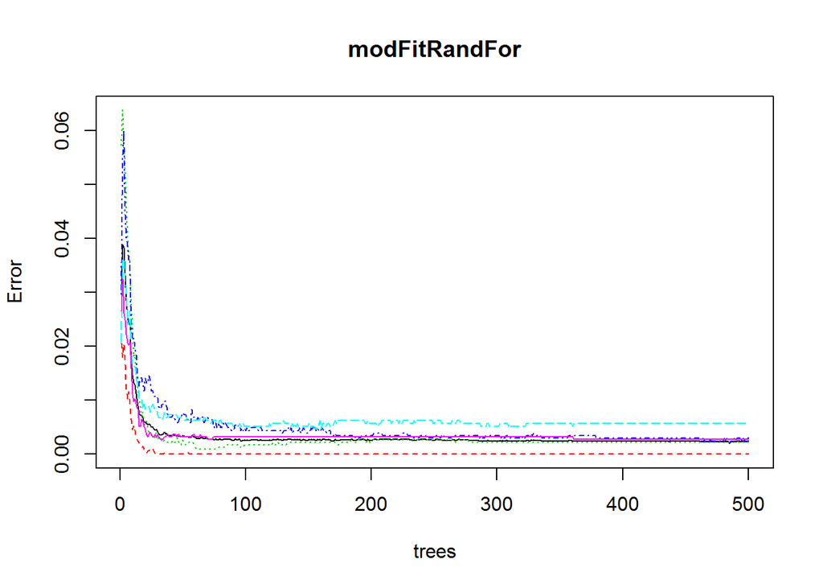

```r
set.seed(2000)
modFitRandFor <- randomForest(classe ~ ., data=tempTraining)
plot(modFitRandFor)
```

```r
predictRandFor <- predict(modFitRandFor, tempTesting, type = "class")
confMatr <- confusionMatrix(predictRandFor, tempTesting$classe)
confMatr
```

```
## Confusion Matrix and Statistics
##
##           Reference
## Prediction    A    B    C    D    E
##          A 2232    4    0    0    0
##          B    0 1514    2    0    0
##          C    0    0 1366    4    0
##          D    0    0    0 1282    8
##          E    0    0    0    0 1434
##
## Overall Statistics
##
##                Accuracy : 0.9977
##                  95% CI : (0.9964, 0.9986)
##     No Information Rate : 0.2845
##     P-Value [Acc > NIR] : < 2.2e-16
##
##                   Kappa : 0.9971
##  Mcnemar's Test P-Value : NA
##
## Statistics by Class:
##
##                      Class: A Class: B Class: C Class: D Class: E
## Sensitivity            1.0000   0.9974   0.9985   0.9969   0.9945
## Specificity            0.9993   0.9997   0.9994   0.9988   1.0000
## Pos Pred Value         0.9982   0.9987   0.9971   0.9938   1.0000
## Neg Pred Value         1.0000   0.9994   0.9997   0.9994   0.9988
## Prevalence             0.2845   0.1935   0.1744   0.1639   0.1838
## Detection Rate         0.2845   0.1930   0.1741   0.1634   0.1828
## Detection Prevalence   0.2850   0.1932   0.1746   0.1644   0.1828
## Balanced Accuracy      0.9996   0.9985   0.9990   0.9978   0.9972
```

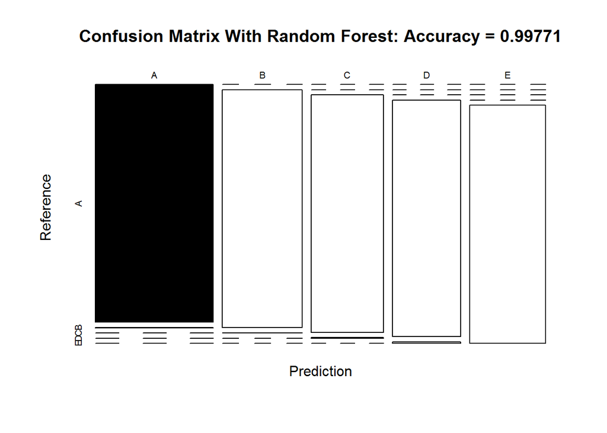

```r
plot(confMatr$table, col = confMatr$byClass, main = paste("Confusion Matrix With Random Forest: Accuracy =", round(confMatr$overall['Accuracy'], 5)))
```

# Predict using Decision Trees

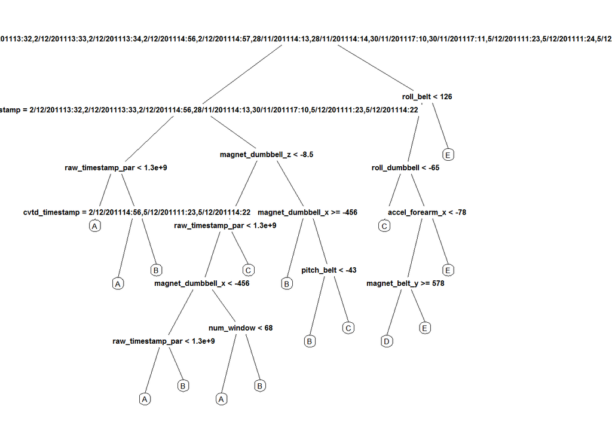

```r
set.seed(2000)
modFitDT <- rpart(classe ~ ., data=tempTraining, method="class")
rpart.plot(modFitDT)
```

```r
predictionDT <- predict(modFitDT, tempTesting, type = "class")
confMatrDT <- confusionMatrix(predictionDT, tempTesting$classe)
confMatrDT
```

```
## Confusion Matrix and Statistics
##
##           Reference
## Prediction    A    B    C    D    E
##          A 2144   62    7    0    0
##          B   59 1260   72   50    0
##          C   29  184 1261  216   53
##          D    0   12   16  808  102
##          E    0    0   12  212 1287
##
## Overall Statistics
##
##                Accuracy : 0.8616
##                  95% CI : (0.8537, 0.8692)
##     No Information Rate : 0.2845
##     P-Value [Acc > NIR] : < 2.2e-16
##
##                   Kappa : 0.8249
##  Mcnemar's Test P-Value : NA
##
## Statistics by Class:
##
##                      Class: A Class: B Class: C Class: D Class: E
## Sensitivity            0.9606   0.8300   0.9218   0.6283   0.8925
## Specificity            0.9877   0.9714   0.9256   0.9802   0.9650
## Pos Pred Value         0.9688   0.8744   0.7235   0.8614   0.8518
## Neg Pred Value         0.9844   0.9597   0.9825   0.9308   0.9755
## Prevalence             0.2845   0.1935   0.1744   0.1639   0.1838
## Detection Rate         0.2733   0.1606   0.1607   0.1030   0.1640
## Detection Prevalence   0.2821   0.1837   0.2222   0.1196   0.1926
## Balanced Accuracy      0.9741   0.9007   0.9237   0.8042   0.9288
```

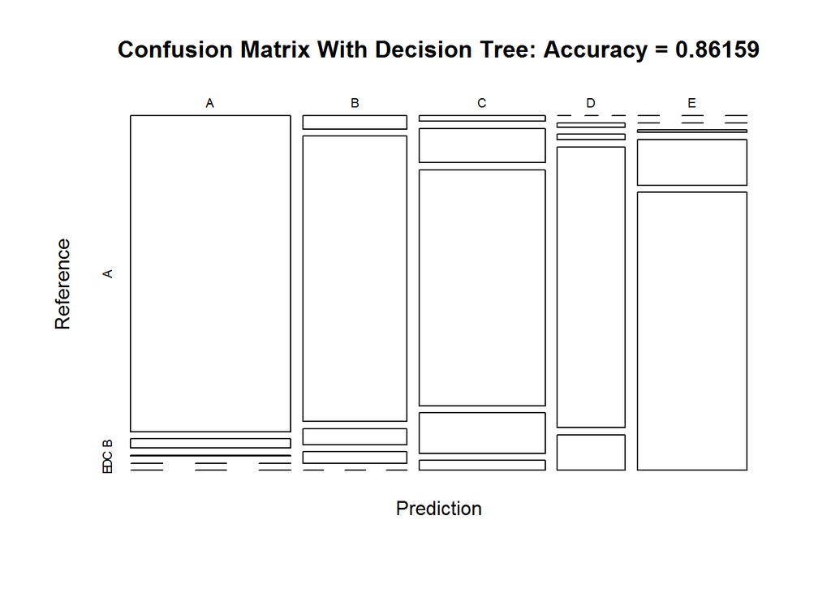

```r
plot(confMatrDT$table, col = confMatrDT$byClass, main = paste("Confusion Matrix With Decision Tree: Accuracy =", round(confMatrDT$overall['Accuracy'], 5)))
```

# Course Project Prediction Quiz Results

```r
predictCourseQuiz <- predict(modFitRandFor, dfTest, type = "class")
predictCourseQuiz
```

```
##  2  3  4  5 61  7  8  9 10 11 12 13 14 15 16 17 18 19 20 21
##  B  A  B  A  A  E  D  B  A  A  B  C  B  A  E  E  A  B  B  B
## Levels: A B C D E
```